# MachineLearningProject

yohan

30 de agosto de 2019

# Summary

Using devices such as Jawbone Up, Nike FuelBand, and Fitbit it is now possible to collect a large amount of data about personal activity relatively inexpensively. These type of devices are part of the quantified self movement - a group of enthusiasts who take measurements about themselves regularly to improve their health, to find patterns in their behavior, or because they are tech geeks. One thing that people regularly do is quantify how much of a particular activity they do, but they rarely quantify how well they do it.

## Objective:

Goal will be to use data from accelerometers on the belt, forearm, arm, and dumbell of 6 participants. They were asked to perform barbell lifts correctly and incorrectly in 5 different ways. Predict the outcome of the variable classe in the training set.

### Set of libraries

```r
library(caret)
```

```r
library(rpart)
library(rpart.plot)
library(randomForest)
library(rattle)
library(knitr)
library(dplyr)
```

### Load Data

```r
Train <- read.csv(file='pml-training.csv', header = TRUE, sep = ',',na.strings=c( "", "#DIV/0!","NA"))
Test <- read.csv(file='pml-testing.csv', header = TRUE, sep = ',' ,na.strings=c( "", "#DIV/0!","NA"))
```

### dimention of sets of Data

```r
dim(Train)
```

```
## [1] 19622   160
```

```r
dim(Test)
```

```
## [1]  20 160
```

Dimentions of trainning data are Rows=19622 columns=160 esting data = Rows = 20 columns=160

### Clean Data

If we make a summary rain and Test we can see a lot NA data so we have to clean Changin NA BY 0

```r
Train[is.na(Train)] <- 0
Test[is.na(Test)] <- 0
```

```r
summary(Train$classe)
```

```
##    A    B    C    D    E
## 5580 3797 3422 3216 3607
```

### Lets selects variables that are useful

```r
Train <- select(Train,(8:160))
Test <- select(Test,(8:160))
```

### Lests takeout de columns with “total” since might be dirty data for the porpouse.

```r
CleanTrain <-  select (Train, -"total_accel_belt", -"total_accel_arm", -"total_accel_dumbbell", -"total_accel_forearm")
CleanTest <- select (Test, -"total_accel_belt", -"total_accel_arm", -"total_accel_dumbbell", -"total_accel_forearm")
```

### Partitioning of Data

```r
Traini<-createDataPartition(y=CleanTrain$classe, p=0.75, list=FALSE)
Trainsub<-CleanTrain[Traini,]
Testsub<-CleanTrain[-Traini,]
```

### dimention of sets of subData

```r
dim(Trainsub)
```

```
## [1] 14718   149
```

```r
dim(Testsub)
```

```
## [1] 4904  149
```

## Decision Tree

[figure not shown]

```r
set.seed(2019)
Treefit <- rpart(classe ~ ., data=Trainsub, method="class")
fancyRpartPlot(Treefit)
```

###Lets predict with decision tree

```r
set.seed(2019)
Treefitest <- predict(Treefit, Testsub, type = "class")
confusionMatrix(Treefitest,Testsub$classe)
```

```
## Confusion Matrix and Statistics
##
##           Reference
## Prediction    A    B    C    D    E
##          A 1234  202   19   83   37
##          B   35  507   73   21   54
##          C   44  129  670  117  107
##          D   52   40   70  524   53
##          E   30   71   23   59  650
##
## Overall Statistics
##
##                Accuracy : 0.731
##                  95% CI : (0.7184, 0.7434)
##     No Information Rate : 0.2845
##     P-Value [Acc > NIR] : < 2.2e-16
##
##                   Kappa : 0.6585
##
##  Mcnemar's Test P-Value : < 2.2e-16
##
## Statistics by Class:
##
##                      Class: A Class: B Class: C Class: D Class: E
## Sensitivity            0.8846   0.5342   0.7836   0.6517   0.7214
## Specificity            0.9028   0.9537   0.9020   0.9476   0.9543
## Pos Pred Value         0.7835   0.7348   0.6279   0.7091   0.7803
## Neg Pred Value         0.9516   0.8951   0.9518   0.9328   0.9383
## Prevalence             0.2845   0.1935   0.1743   0.1639   0.1837
## Detection Rate         0.2516   0.1034   0.1366   0.1069   0.1325
## Detection Prevalence   0.3212   0.1407   0.2176   0.1507   0.1699
## Balanced Accuracy      0.8937   0.7440   0.8428   0.7997   0.8379
```

## Ramdon forest Train

```r
Forestfitrain <- randomForest(classe ~ ., data=Trainsub)
Forestfitrain
```

```
##
## Call:
##  randomForest(formula = classe ~ ., data = Trainsub)
##                Type of random forest: classification
##                      Number of trees: 500
## No. of variables tried at each split: 12
##
##         OOB estimate of  error rate: 0.57%
## Confusion matrix:
##      A    B    C    D    E  class.error
## A 4183    2    0    0    0 0.0004778973
## B   14 2828    6    0    0 0.0070224719
## C    0   16 2547    4    0 0.0077911959
## D    0    0   31 2379    2 0.0136815920
## E    0    0    2    7 2697 0.0033259424
```

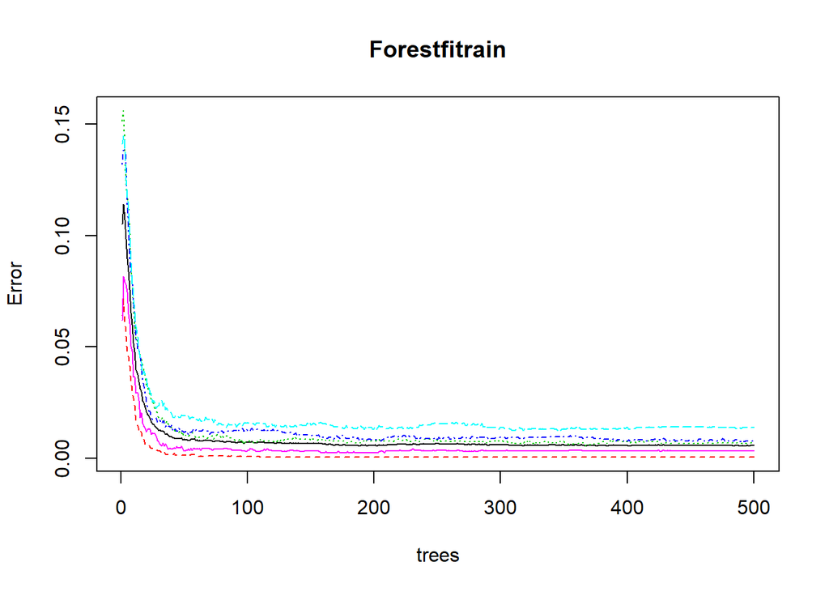

```r
plot(Forestfitrain)
```

```r
predforest <- predict(Forestfitrain, Testsub, type = "class")
Pred <- confusionMatrix(predforest, Testsub$classe)
Pred
```

```
## Confusion Matrix and Statistics
##
##           Reference
## Prediction    A    B    C    D    E
##          A 1394    1    0    0    0
##          B    0  948    8    0    0
##          C    0    0  846    8    0
##          D    0    0    1  796    1
##          E    1    0    0    0  900
##
## Overall Statistics
##
##                Accuracy : 0.9959
##                  95% CI : (0.9937, 0.9975)
##     No Information Rate : 0.2845
##     P-Value [Acc > NIR] : < 2.2e-16
##
##                   Kappa : 0.9948
##
##  Mcnemar's Test P-Value : NA
##
## Statistics by Class:
##
##                      Class: A Class: B Class: C Class: D Class: E
## Sensitivity            0.9993   0.9989   0.9895   0.9900   0.9989
## Specificity            0.9997   0.9980   0.9980   0.9995   0.9998
## Pos Pred Value         0.9993   0.9916   0.9906   0.9975   0.9989
## Neg Pred Value         0.9997   0.9997   0.9978   0.9981   0.9998
## Prevalence             0.2845   0.1935   0.1743   0.1639   0.1837
## Detection Rate         0.2843   0.1933   0.1725   0.1623   0.1835
## Detection Prevalence   0.2845   0.1949   0.1741   0.1627   0.1837
## Balanced Accuracy      0.9995   0.9985   0.9937   0.9948   0.9993
```

### Let make a prediction with the data delivered at the begining of the exercise

```r
finalPred <- predict(Forestfitrain, CleanTest, type = "class")
finalPred
```

```
##  1  2  3  4  5  6  7  8  9 10 11 12 13 14 15 16 17 18 19 20
##  B  A  B  A  A  E  D  B  A  A  B  C  B  A  E  E  A  B  B  B
## Levels: A B C D E
```